# Time Series Decomposition

Author

Dr. Cohen

The first step in analyzing any time series is plotting the data. Inspection of the graph may suggest the possibility of representing the data as follows (the classical decomposition):

$$X_t = m_t + s_t + Y_t$$
where

- $m_t$ is the trend component
- $s_t$ is the seasonal component
- $Y_t$ random noise component / Residuals

if seasonality and noise fluctuations (variability) appear to increase with the level of the process (trend), then use a preliminary transformation of the data (natural logarithm,…).

We are going to learn how to estimate and eliminate the trend and the seasonal components in the hope that the residual $Y_t$ will be a **stationary time series.**

```r
# Load packages
library(itsmr)
library(tidyverse)
library(tsibble)
library(feasts)
```

## Trend Estimation

Strikes in the USA from 1951-1980

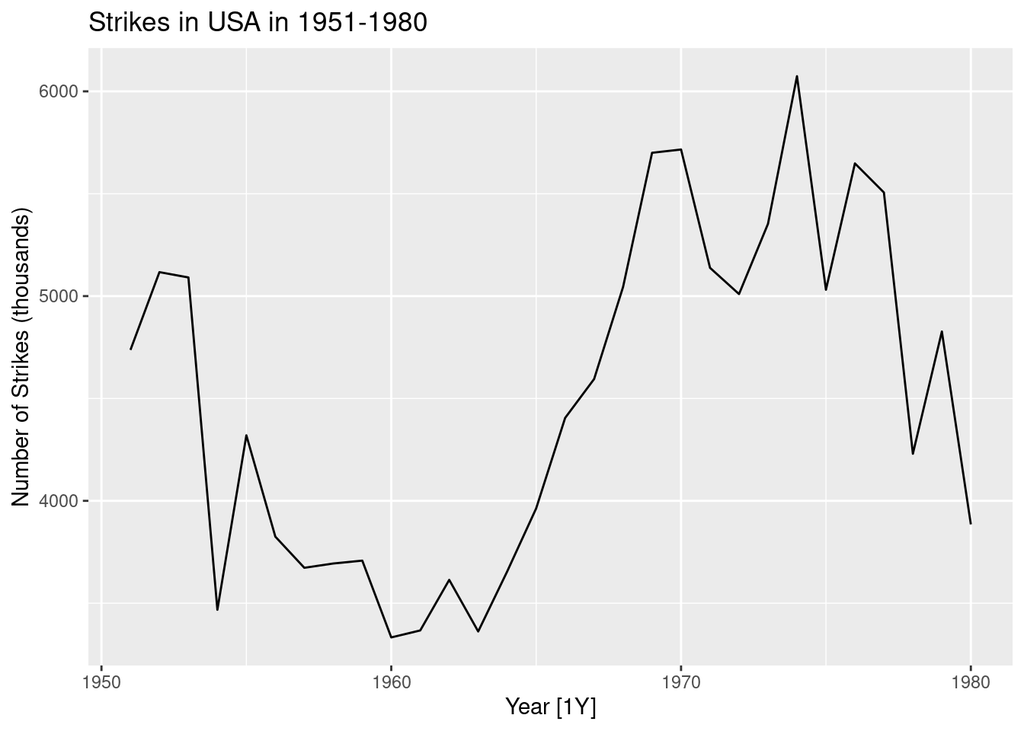

```r
strikes = read.table("http://users.stat.umn.edu/~kb/classes/5932/data/strikes.txt", header = FALSE)

# get data to tsibble format
strikes = strikes %>%
  mutate(Year=seq(1951,1980,1)) %>%
  as_tsibble(index = Year)

# plot the time series
strikes %>%
  autoplot(V1) +
  labs(y="Number of Strikes (thousands)",
       title="Strikes in USA in 1951-1980")
```

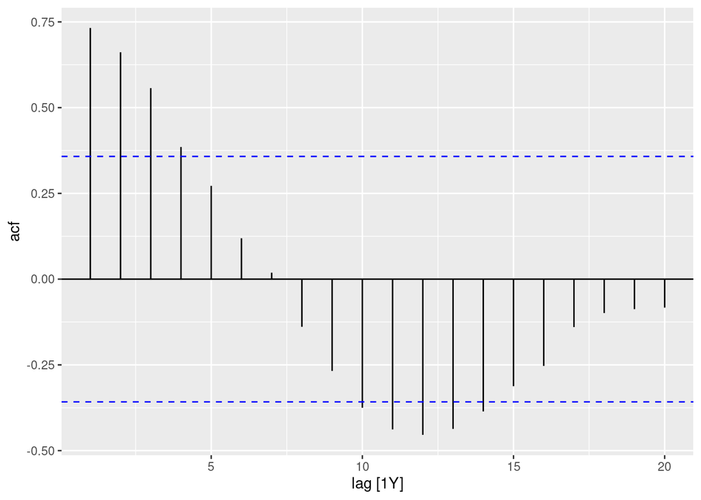

```r
# plot the ACF
strikes %>%
  ACF(V1, lag_max = 20) %>%
  autoplot()
```

#### Trend Estimation: Smoothing Moving Average

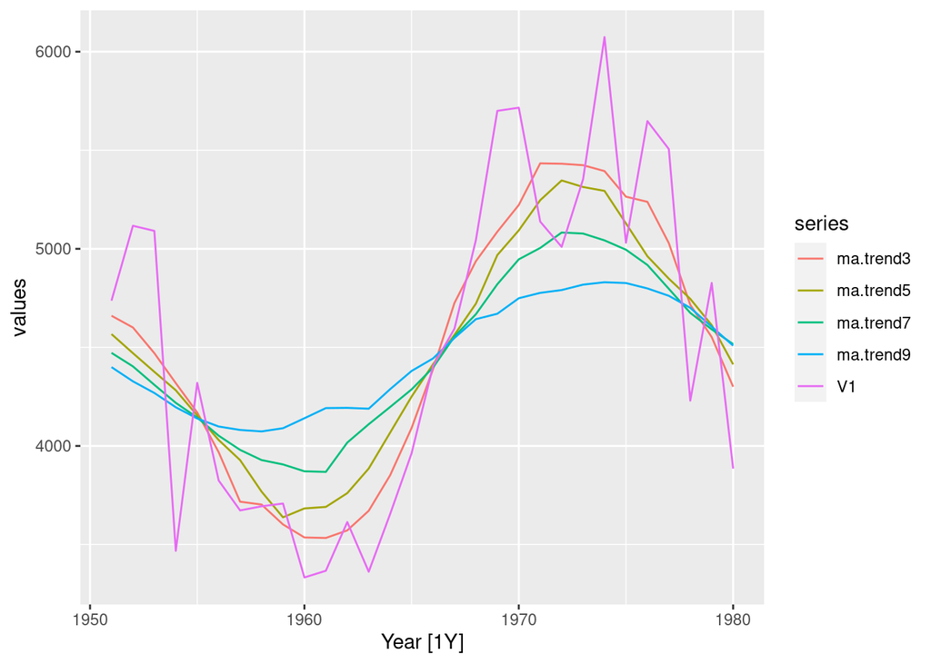

```r
strikes %>%
  mutate(ma.trend3 = smooth.ma(V1, 3),
         ma.trend5 = smooth.ma(V1, 5),
         ma.trend7 = smooth.ma(V1, 7),
         ma.trend9 = smooth.ma(V1, 9)) %>% # q=3 means averaging 2q+1 values
  pivot_longer(cols =-Year,
               names_to = "series",
               values_to = "values") %>%
    group_by(series) %>%
    autoplot(values)
```

#### Trend Estimation: Exponential Smoothing

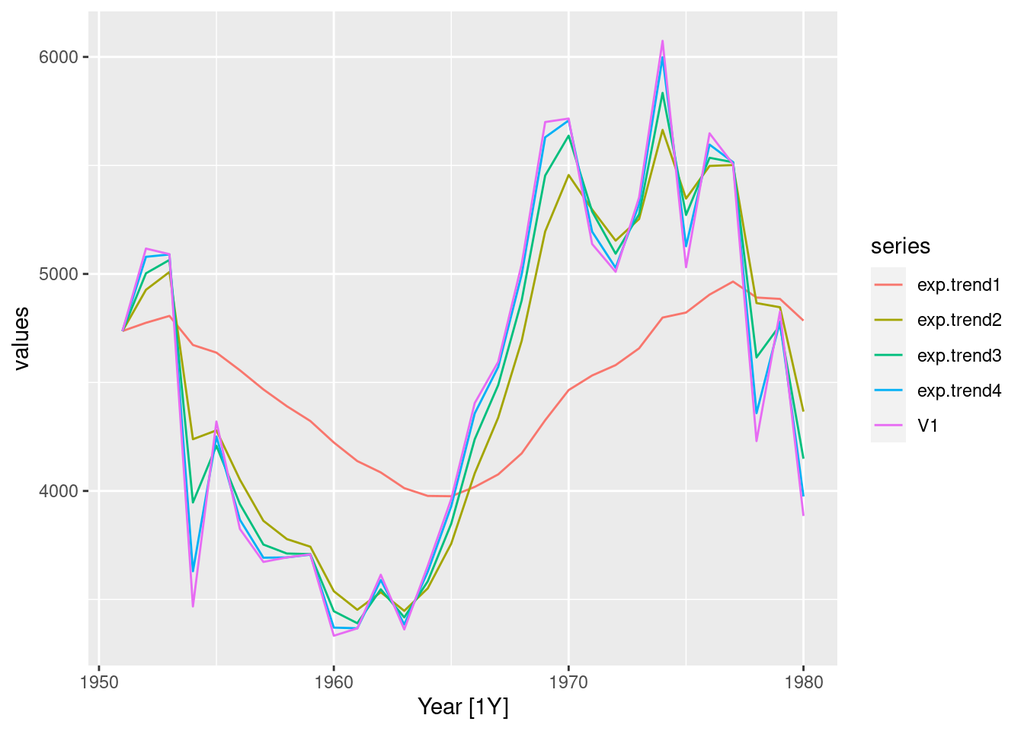

```r
strikes %>%
  mutate(exp.trend1 = smooth.exp(V1, 0.1),# alpha=0.1 mis the smootheness parameter
         exp.trend2 = smooth.exp(V1, 0.5),
         exp.trend3 = smooth.exp(V1, 0.7),
         exp.trend4 = smooth.exp(V1, 0.9)) %>%
  pivot_longer(cols =-Year,
               names_to = "series",
               values_to = "values") %>%
    group_by(series) %>%
    autoplot(values)
```

#### Trend Estimation: FFT

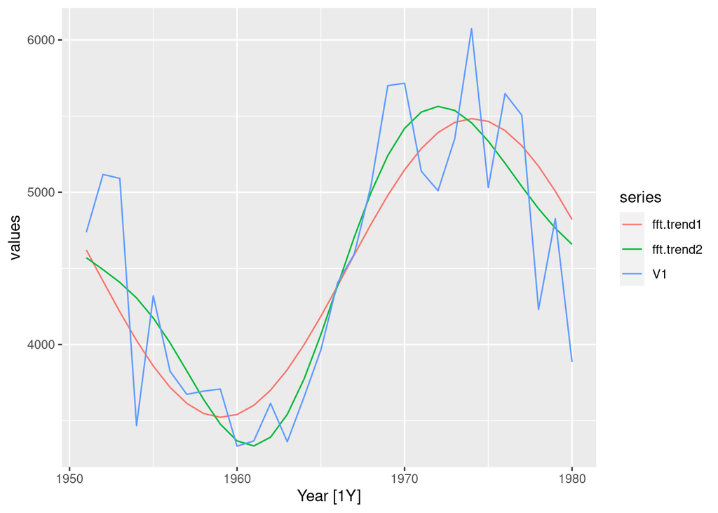

```r
strikes %>%
  mutate(fft.trend1 = smooth.fft(V1, 0.1),# 0.1 is cutoff frequency - 10% of the lowest spectrum passes
         fft.trend2 = smooth.fft(V1, 0.25)) %>%
  pivot_longer(cols =-Year,
               names_to = "series",
               values_to = "values") %>%
    group_by(series) %>%
    autoplot(values)
```

#### Trend Estimation: Regression

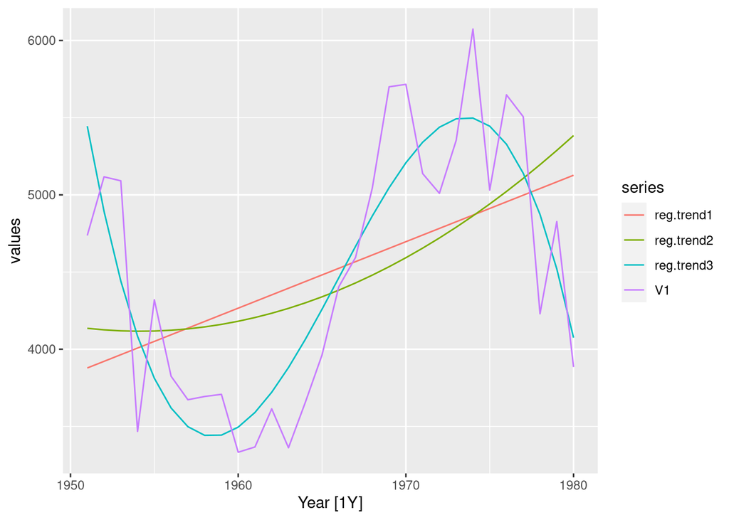

```r
strikes %>%
  mutate(reg.trend1 = trend(V1, 1),# 1 means polynmial of degree 1
         reg.trend2 = trend(V1, 2),
         reg.trend3 = trend(V1, 3)) %>%
  pivot_longer(cols =-Year,
               names_to = "series",
               values_to = "values") %>%
    group_by(series) %>%
    autoplot(values)
```

## Seasonality Estimation

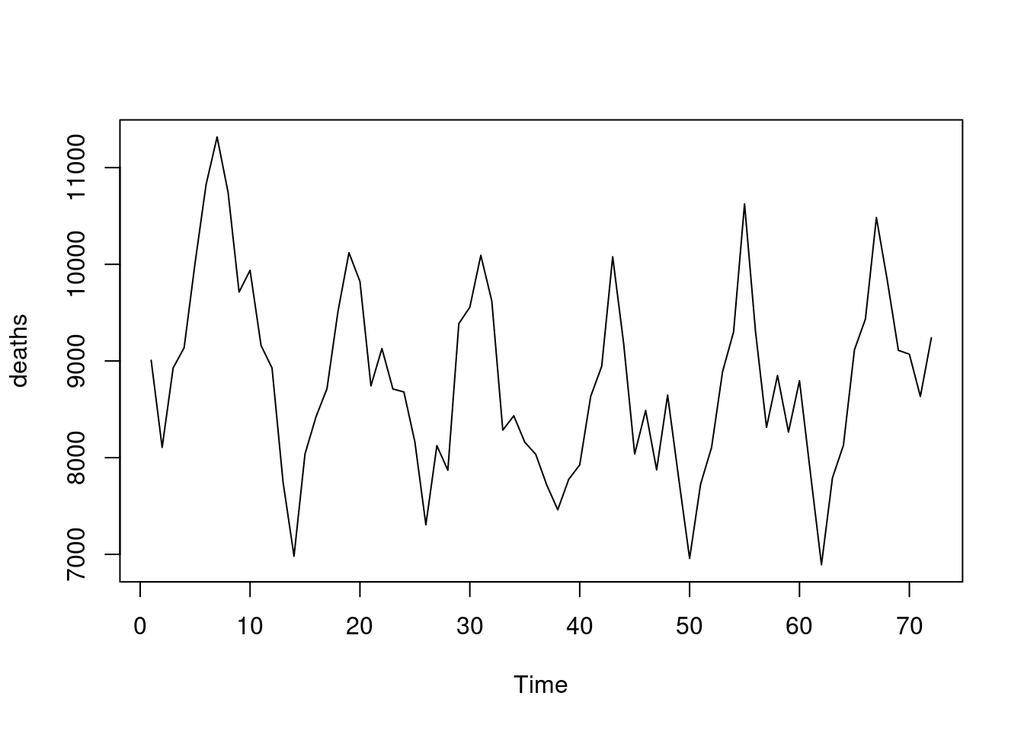

```r
plot.ts(deaths)
```

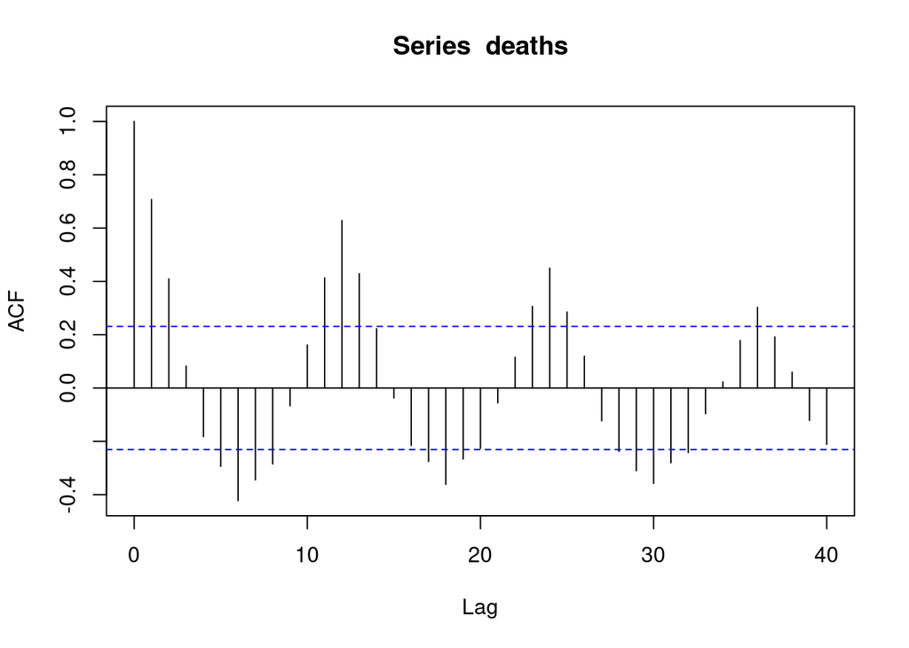

```r
acf(deaths,lag.max=40)
```

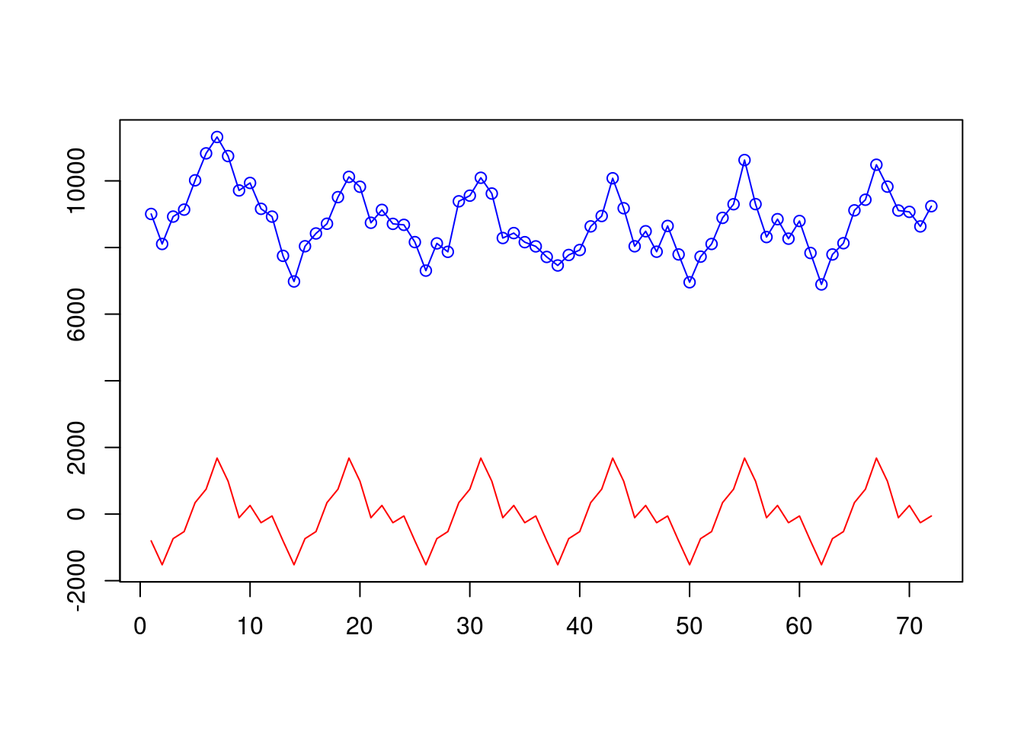

```r
estimate.season = season(deaths, d=12)
plotc(deaths,estimate.season)
```

```
Null hypothesis: Residuals are iid noise.
Test                        Distribution Statistic   p-value
Ljung-Box Q                Q ~ chisq(20)     202.4         0 *
McLeod-Li Q                Q ~ chisq(20)    205.08         0 *
Turning points T   (T-46.7)/3.5 ~ N(0,1)        43    0.2993
Diff signs S       (S-35.5)/2.5 ~ N(0,1)        36    0.8394
Rank P           (P-1278)/102.9 ~ N(0,1)       971    0.0028 *
```

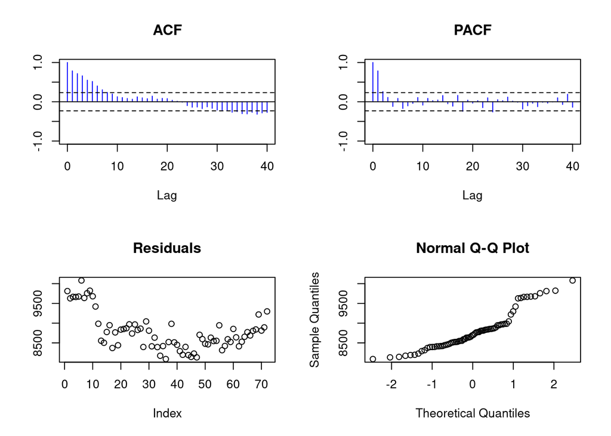

```r
r = deaths-estimate.season
test(r)
```

#### Test IID hypothesis for the residuals

Use the`Resid()` function to find the residuals.

```
Null hypothesis: Residuals are iid noise.
Test                        Distribution Statistic   p-value
Ljung-Box Q                Q ~ chisq(20)    133.05         0 *
McLeod-Li Q                Q ~ chisq(20)     51.85     1e-04 *
Turning points T   (T-46.7)/3.5 ~ N(0,1)        41    0.1087
Diff signs S       (S-35.5)/2.5 ~ N(0,1)        37    0.5431
Rank P           (P-1278)/102.9 ~ N(0,1)      1368    0.3816
```

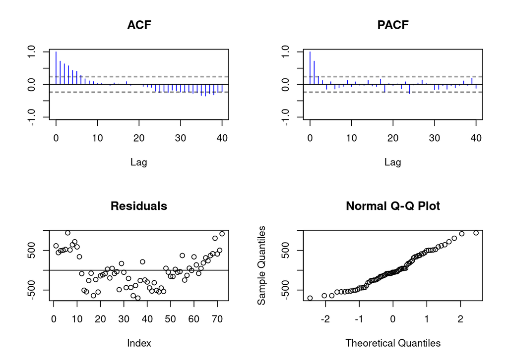

```r
# deaths
data.model = c("season",12,"trend",1) # from examining the series
R= Resid(deaths,data.model)
# Test IDD
test(R) # need to tests to fail to reject the null hypothesis
```

```
Null hypothesis: Residuals are iid noise.
Test                        Distribution Statistic   p-value
Ljung-Box Q                Q ~ chisq(20)      9.55    0.9757
McLeod-Li Q                Q ~ chisq(20)      8.87    0.9843
Turning points T   (T-18.7)/2.2 ~ N(0,1)        17    0.4566
Diff signs S       (S-14.5)/1.6 ~ N(0,1)        16    0.3507
Rank P             (P-217.5)/28 ~ N(0,1)       217    0.9858
```

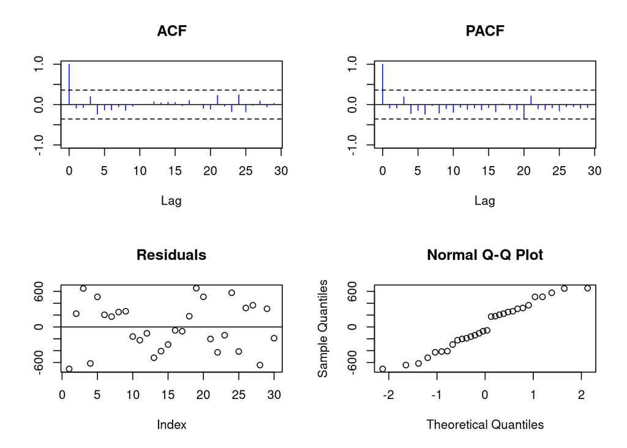

```r
# strikes
data.model.s = c("trend",3)
R.s= Resid(strikes$V1,data.model.s)
# Test IDD
test(R.s)
```

### Trend and Seasonality Elimination using the Differencing operator

#### JohnsonJohnson quarterly earnings data:

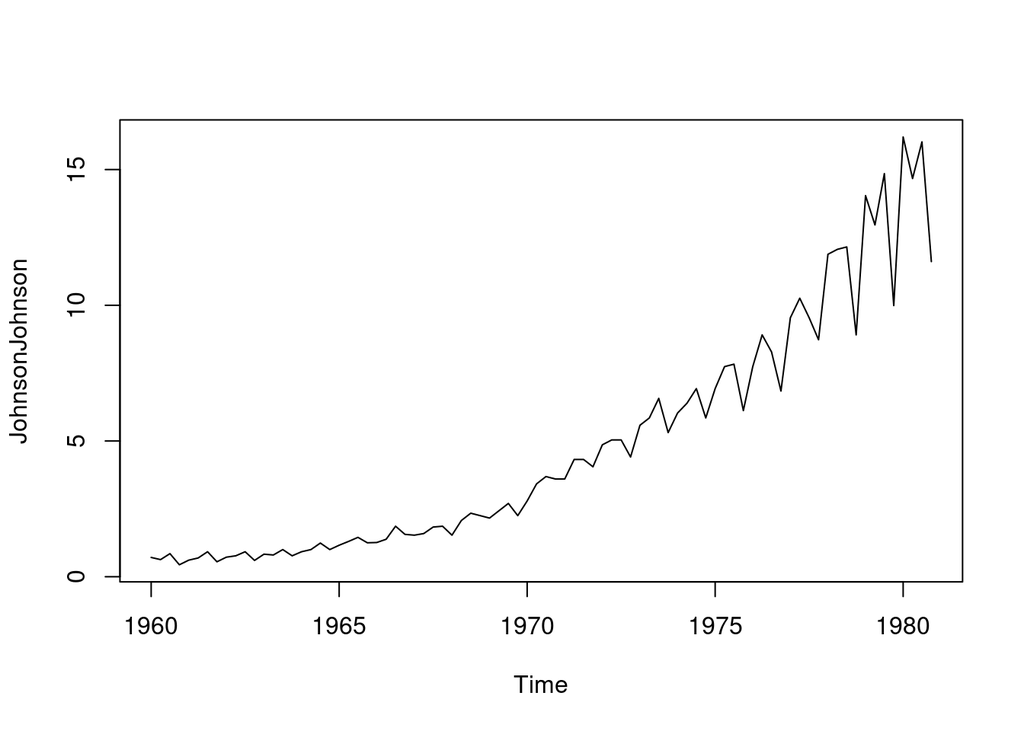

```r
plot.ts(JohnsonJohnson)
```

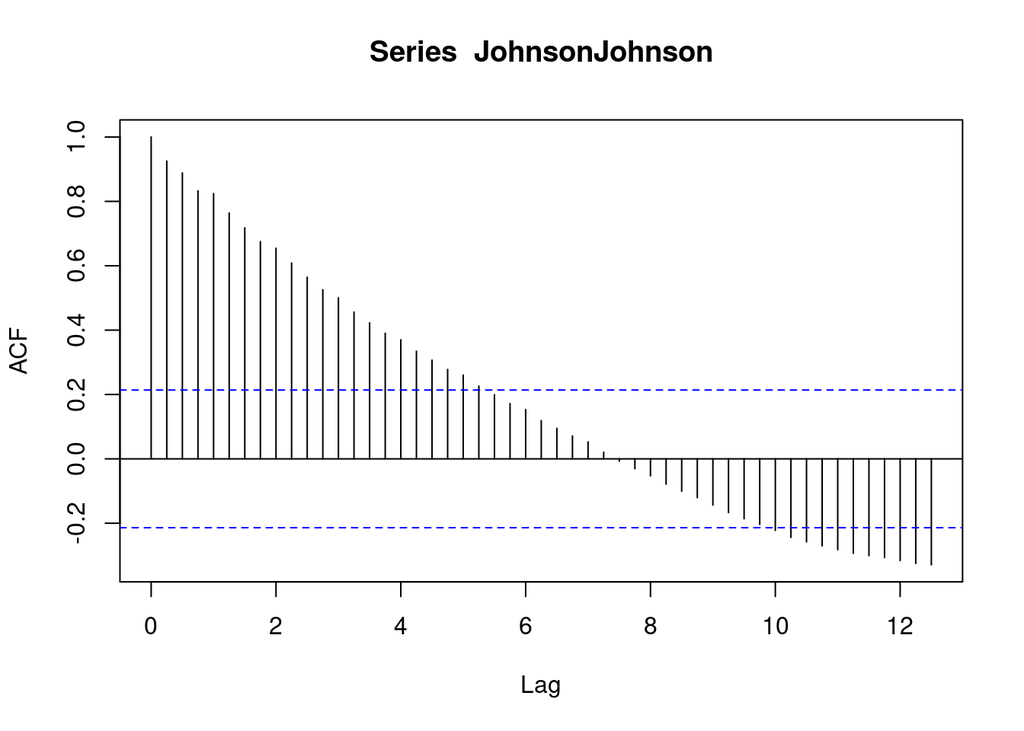

```r
acf(JohnsonJohnson,lag.max = 50)
```

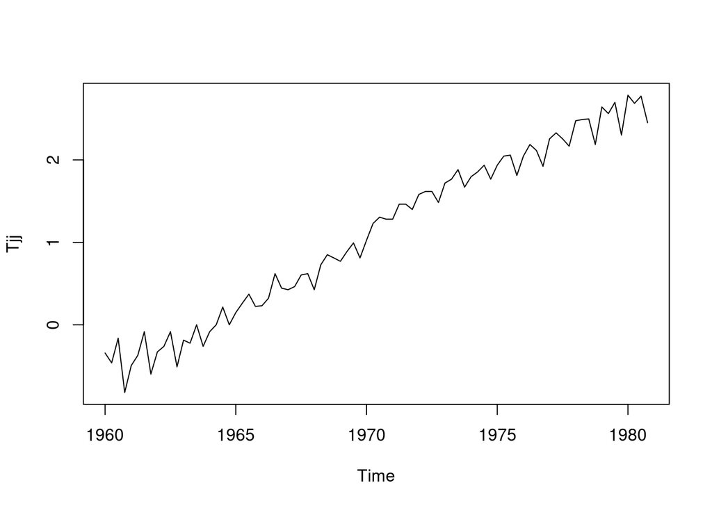

```r
# Transformation
library(car)
L = powerTransform(JohnsonJohnson)
Tjj = log(JohnsonJohnson)

plot.ts(Tjj)
```

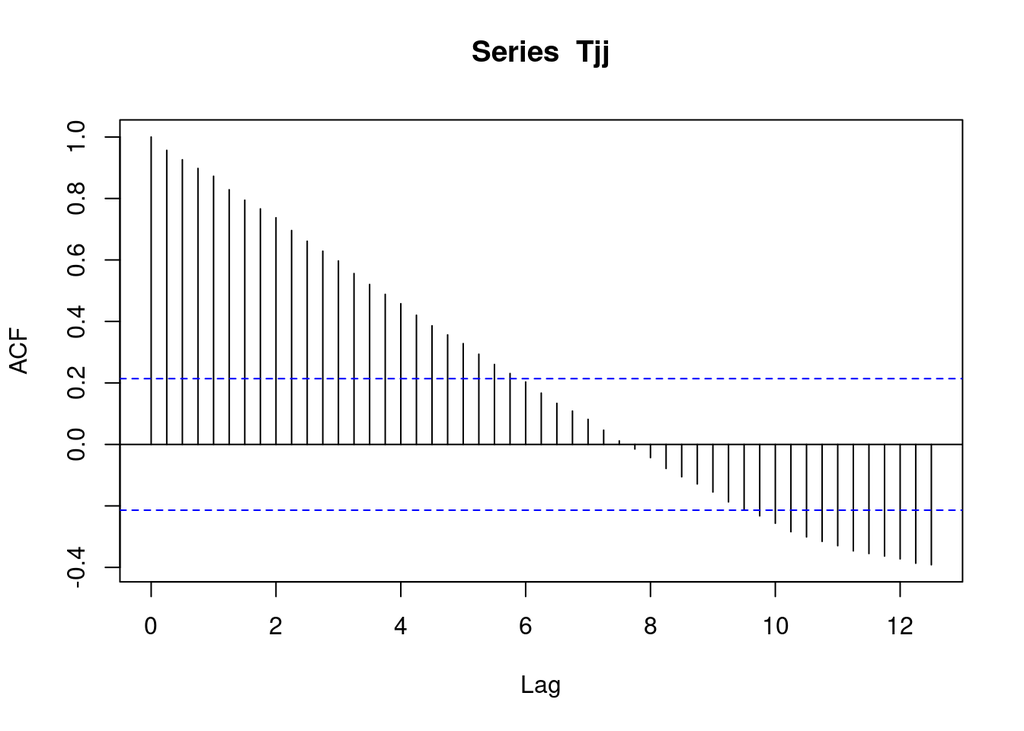

```r
acf(Tjj,lag.max = 50)
```

$$X_t = m_t + Y_t$$

```
Null hypothesis: Residuals are iid noise.
Test                        Distribution Statistic   p-value
Ljung-Box Q                Q ~ chisq(20)    103.25         0 *
McLeod-Li Q                Q ~ chisq(20)     42.54    0.0023 *
Turning points T   (T-54.7)/3.8 ~ N(0,1)        48    0.0811
Diff signs S       (S-41.5)/2.7 ~ N(0,1)        44    0.3476
Rank P           (P-1743)/129.4 ~ N(0,1)      1829    0.5064
```

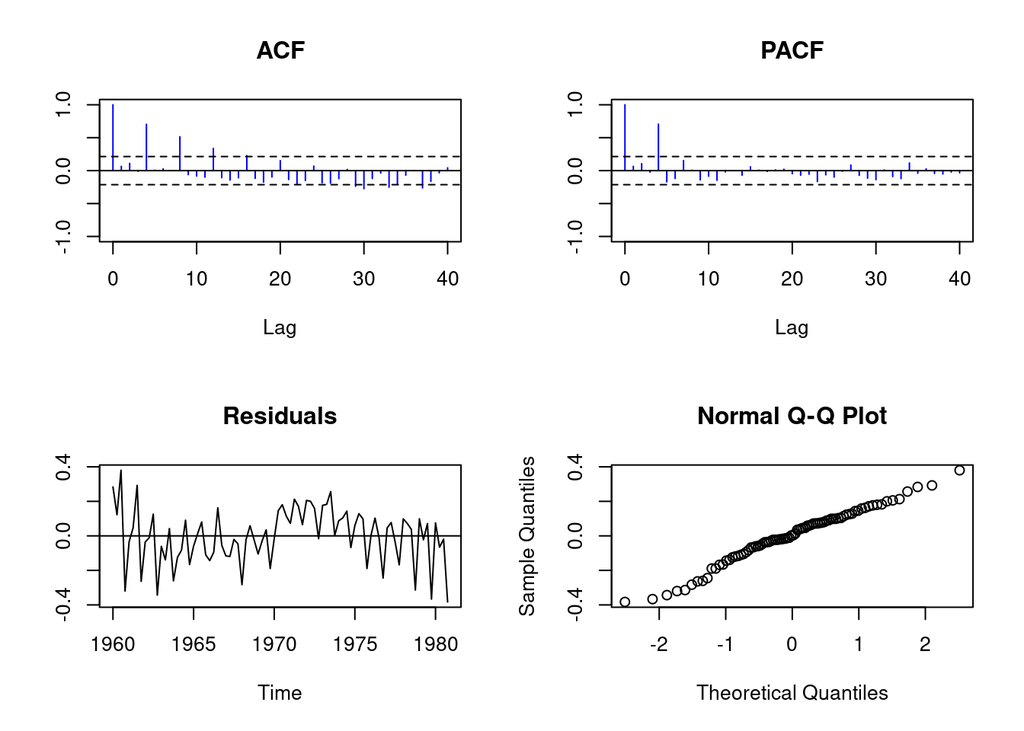

```r
# Estimations
jj.data.model = c("log","trend",1)
r.jj = Resid(JohnsonJohnson,jj.data.model)
test(r.jj)
```

It looks like we have a season of *period 4* Then,

$$X_t = m_t + S_t + Y_t$$

and

```
Null hypothesis: Residuals are iid noise.
Test                        Distribution Statistic   p-value
Ljung-Box Q                Q ~ chisq(20)     74.51         0 *
McLeod-Li Q                Q ~ chisq(20)     14.92    0.7808
Turning points T   (T-54.7)/3.8 ~ N(0,1)        54    0.8615
Diff signs S       (S-41.5)/2.7 ~ N(0,1)        42     0.851
Rank P           (P-1743)/129.4 ~ N(0,1)      1812     0.594
```

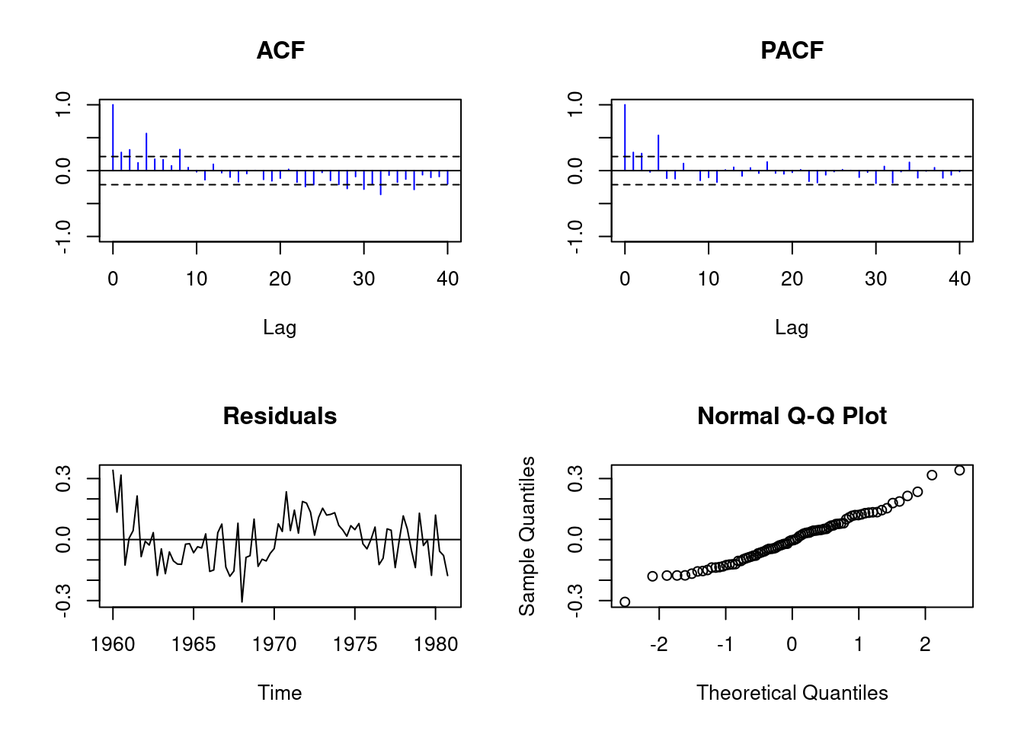

```r
# Estimation
jj.data.model = c("log","trend",2,"season",4)
r.jj = Resid(JohnsonJohnson,jj.data.model)
test(r.jj)
```

By Elimination we have the following:

$$y_t = \nabla^2 \nabla_4 \log(X_t)$$

rewrite this as:

Eliminate Season

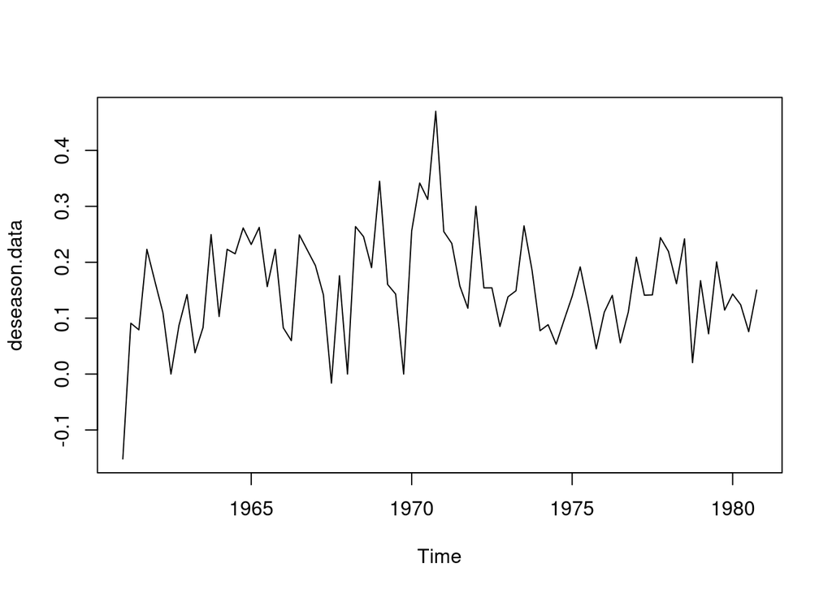

```r
deseason.data = diff(log(JohnsonJohnson),lag = 4)
plot(deseason.data)
```

Eliminate Trend

```r
residual.data = diff(deseason.data,lag = 1,differences = 2)
```

Test IID for the residuals

```
Null hypothesis: Residuals are iid noise.
Test                        Distribution Statistic   p-value
Ljung-Box Q                Q ~ chisq(20)    103.69         0 *
McLeod-Li Q                Q ~ chisq(20)     30.03    0.0694
Turning points T   (T-50.7)/3.7 ~ N(0,1)        62    0.0021 *
Diff signs S       (S-38.5)/2.6 ~ N(0,1)        41    0.3299
Rank P         (P-1501.5)/115.9 ~ N(0,1)      1529    0.8124
```

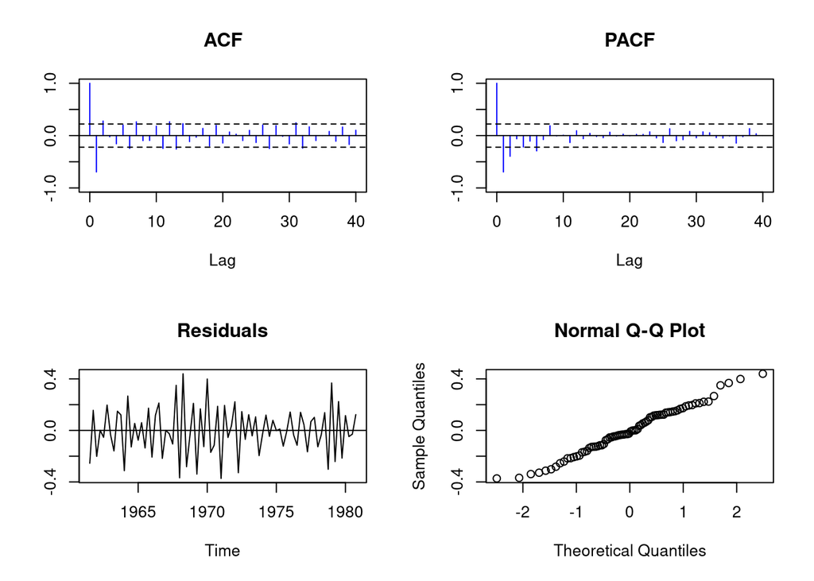

```r
test(residual.data)
```

Since at least one test is reject the hypothesis of IID, therefore further analysis to be done.